# PGx analysis

```r
library("ggpubr")
```

reading data

```r
library(readxl)
responses <- read_excel("Genetic Counselors Knowledge of Pharmacogenomics.xlsx",
     skip = 2)
```

counting responses to each question

```r
responses$q2 <- as.integer(responses$question_2=="CYP2C19 *1")
responses$q3 <- as.integer(responses$question_3=="Codeine")
responses$q4 <- as.integer(responses$question_4=="They are an ultra-metabolizer")
responses$q5 <- as.integer(responses$question_5=="Increased enzyme activity, causing someone to experience symptoms of a higher dose of the drug than they were given")
responses$q6 <- as.integer(responses$question_6=="False")
responses$q7 <- as.integer(responses$question_7!="Never")
responses$q8 <- as.integer((responses$question_8=="Agree" | responses$question_8=="Strongly agree"))
responses$q9 <- as.integer((responses$question_9=="Agree" | responses$question_9=="Strongly agree"))
responses$q10 <- as.integer(as.factor(responses$question_10))
responses$q13 <- as.integer(as.factor(responses$question_13))
```

converting NA responses to a zero value

```r
responses[is.na(responses)] <- 0
```

summation of correct answers in questions 2 through 6

```r
responses$knowledgesum <- responses$q2+responses$q3+responses$q4+responses$q5+responses$q6
```

number of participants that have greater than 2 questions correct within questions 2 through 6

```r
sum(responses$knowledgesum>2)
```

```
[1] 45
```

summation of correct answers in questions 2 through 9

```r
responses$totalsum <- responses$q2+responses$q3+responses$q4+responses$q5+responses$q6+responses$q7+responses$q8+responses$q9
```

number of participants that have greater than 4 questions correct within questions 2 through 9

```r
sum(responses$totalsum>4)
```

```
[1] 32
```

correlation test between knowledge and relevancy score and when someone graduated

```r
cor.test(responses$q10, responses$totalsum, method = "pearson")
```

```
    Pearson's product-moment correlation

data:  responses$q10 and responses$totalsum
t = -2.4339, df = 223, p-value = 0.01572
alternative hypothesis: true correlation is not equal to 0
95 percent confidence interval:
 -0.28564313 -0.03071785
sample estimates:
       cor
-0.1608622
```

graph of above correlation test

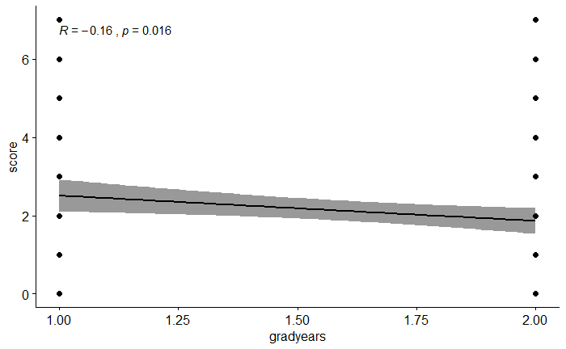

```r
ggscatter(responses, x = "q10", y = "totalsum",
          add = "reg.line", conf.int = TRUE,
          cor.coef = TRUE, cor.method = "pearson",
          xlab = "gradyears", ylab = "score")
```

correlation test between agreeing with pharmacogenomic relevancy and what type of position the GC works in

```r
cor.test(responses$q13, as.integer(responses$q9), method = "pearson")
```

```
    Pearson's product-moment correlation

data:  responses$q13 and as.integer(responses$q9)
t = 3.5394, df = 223, p-value = 0.000488
alternative hypothesis: true correlation is not equal to 0
95 percent confidence interval:
 0.1029401 0.3508339
sample estimates:
      cor
0.2306257
```

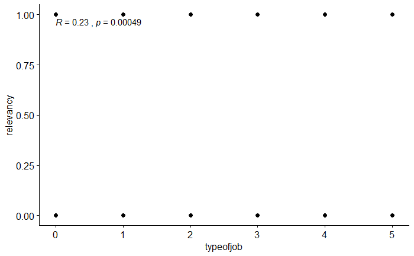

```r
ggscatter(responses, x = "q13", y = "q9",
          conf.int = TRUE,
          cor.coef = TRUE, cor.method = "pearson",
          xlab = "typeofjob", ylab = "relevancy")
```

```r
table(as.factor(responses$question_13))
```

```
                             0               Clinical setting              Education setting
                             2                            153                             10
Industry or laboratory setting                          Other               Research setting
                            38                              9                             13
```

```r
table(as.integer(as.factor(responses$question_13))-1)
```

```
  0   1   2   3   4   5
  2 153  10  38   9  13
```

Group/count of job type and X is if pharmacogenomics is relevant or not

```r
res <- aggregate(responses$q9, by=list(responses$question_13, responses$q9), FUN=length)
res[res$Group.2 == 1,]
```

|  | Group.1 | Group.2 | x |
| --- | --- | --- | --- |
| 7 | 0 | 1 | 1 |
| 8 | Clinical setting | 1 | 39 |
| 9 | Education setting | 1 | 4 |
| 10 | Industry or laboratory setting | 1 | 21 |
| 11 | Other | 1 | 4 |
| 12 | Research setting | 1 | 7 |

correlation test between agreeing with pharmacogenomic relevancy and years since graduation

```r
cor.test(responses$q10, responses$q9, method = "pearson")
```

```
    Pearson's product-moment correlation

data:  responses$q10 and responses$q9
t = -3.0145, df = 223, p-value = 0.002872
alternative hypothesis: true correlation is not equal to 0
95 percent confidence interval:
 -0.32037232 -0.06886444
sample estimates:
       cor
-0.1978729
```

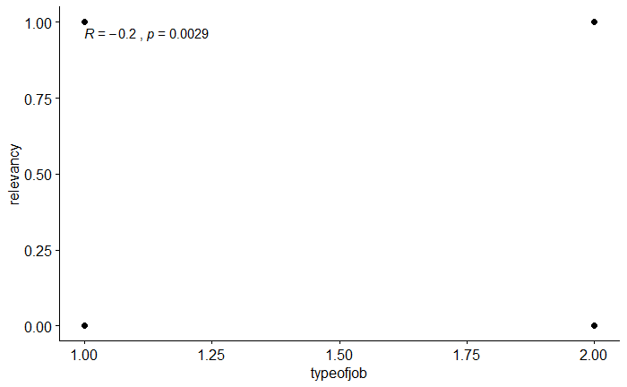

```r
ggscatter(responses, x = "q10", y = "q9",
          conf.int = TRUE,
          cor.coef = TRUE, cor.method = "pearson",
          xlab = "typeofjob", ylab = "relevancy")
```

table so you can correlate the 1 or 2 above to which answer in survey

```r
table(as.factor(responses$question_10))
```

```
  7 or more years ago Less than 7 years ago
                   88                   137
```

```r
table(as.integer(as.factor(responses$question_10)))
```

```
  1   2
 88 137
```

```r
res <- aggregate(responses$q9, by=list(responses$question_10, responses$q9), FUN=length)
res[res$Group.2 == 1,]
```

|  | Group.1 | Group.2 | x |
| --- | --- | --- | --- |
| 3 | 7 or more years ago | 1 | 40 |
| 4 | Less than 7 years ago | 1 | 36 |